# JASHPASAD_24110146_PSDV-Pre-requisites

## PSDV PRE REQUISITES - JASH PASAD - 24110146

### QUESTION 1

### 1. List Operations and Basic Statistics:

- Create a list of the first 20 natural numbers.
- Compute the sum of all even numbers in the list.
- Compute the product of all odd numbers in the list.
- Calculate the mean, median, and standard deviation of the list.

```python
a=list(range(1,21))
s=0
prod=1
for i in a:
    if i%2==0:
        s=s+i
    else:
        prod=prod*i

print(s)
print(prod)

mean=sum(range(1,21))/10
print(mean)

b=len(a)

if b%2==0:
    print((a[b//2-1]+a[b//2]) // 2)
else:
    print(a[b//2])
```

```
110
654729075
21.0
10
```

### QUESTION 2

### 2. Mutable vs. Immutable Data Types:

- Explain the difference between mutable and immutable data types in Python. Provide examples of each.

Solution :- Mutable data types are those that can be changed after they are created. Examples include lists, dictionaries, and sets. Immutable data types are those that cannot be changed after they are created. Examples include strings, tuples, and numbers.

### QUESTION 3

### 3. Fibonacci Sequence:

Write a Python function that takes a number n and returns a list of the first n Fibonacci numbers. Plot the Fibonacci sequence using a line graph.

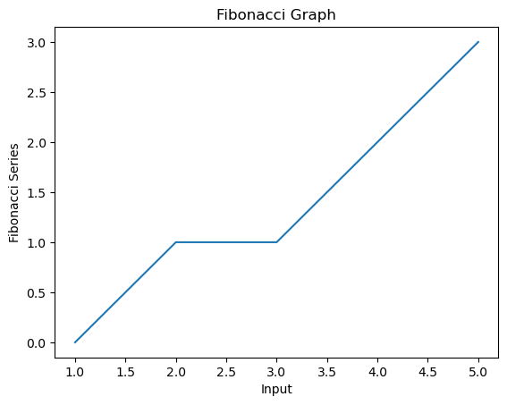

```python
import matplotlib.pyplot as plt
def fibonacci(n):
    if n <= 0:
        return "Incorrect Input"
    series = [0, 1]
    if n > 2:
        for i in range(2, n):
            series.append(series[i-1] + series[i-2])
    return series

n = int(input("Enter num"))
series = fibonacci(n) #this returns array of fibonacci numbers
plt.plot(list(range(1,n+1)),series)
plt.xlabel("Input")
plt.ylabel("Fibonacci Series")
plt.title("Fibonacci Graph")
plt.show()
```

### QUESTION 4

### 4. List Manipulation:

Given a list [3, 5, 7, 9, 11, 13]: Insert 6 at the 3rd index. Remove the number 7 from the list. Reverse the list. Calculate the mean and median of the modified list.

```python
l=[3,5,7,9,11,13]
l.insert(3,6)
l.remove(7)

print(l)

print (sum(l)/len(l))

b=len(l)

if b%2==0:
    print((l[b//2-1]+l[b//2]) // 2)
else:
    print(l[b/2])
```

```
[3, 5, 6, 9, 11, 13]
7.833333333333333
7
```

### QUESTION 5

### 5. User Input and Basic Statistics:

Write a program to read a comma-separated list of numbers from the user (e.g., “10, 20, 30, 40”). Calculate the mean of the numbers. Identify and print the smallest and largest numbers. Plot a histogram of the numbers.

```
10
40
```

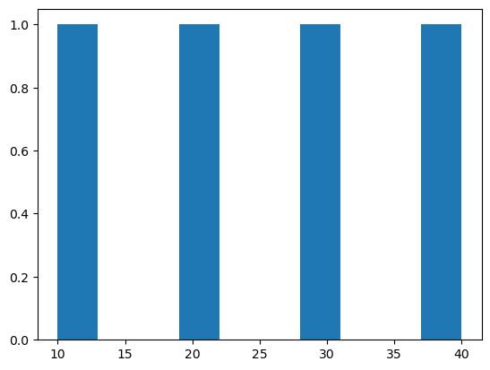

```python
import matplotlib.pyplot as plt
numString = input()
numString = numString.split(',') #spliting numbers
nums = []
#converting string numbers to int numbers
for num in numString:
    nums.append(int(num))
mean = sum(nums)/len(nums)
nums.sort()
print(nums[0])
print(nums[len(nums)-1])
plt.hist(nums)
plt.show()
```

### QUESTION 6

### 6. Palindrome Check:

Write a program to check if a string is a palindrome (ignoring spaces and case). Input: "A man a plan a canal Panama" Output: True

```python
inputStr = input()
inputStr = inputStr.replace(' ','')
inputStr = inputStr.lower()
reverseStr = inputStr[::-1]
if inputStr == reverseStr:
    print(True)
else:
    print(False)
```

```
True
```

### QUESTION 7

### 7. Dictionary Operations:

Create a dictionary of student names (keys) and their marks (values). Compute the average marks. Print the names of students scoring above the average. Visualize the distribution of marks using a bar chart.

I dont know how to use JSON

### QUESTION 8

### 8. Tuple List Creation:

- Create a list of tuples, where each tuple contains a number and its square (e.g., [(1, 1), (2, 4), (3, 9), ...] for numbers 1 to 10).
- Plot the numbers and their squares on a scatter plot.

```
[(1, 1), (2, 4), (3, 9), (4, 16), (5, 25), (6, 36), (7, 49), (8, 64), (9, 81), (10, 100)]
```

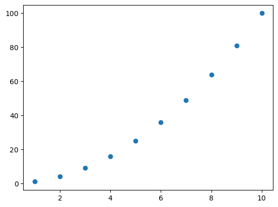

```python
import matplotlib.pyplot as plt
SquareNumbers = []
for i in range(1,11):
    SquareNumbers.append((i,i**2))
print(SquareNumbers)

plt.scatter([num[0] for num in SquareNumbers],[num[1] for num in SquareNumbers])
plt.show()
```

### QUESTION 9

### 9. Merging Dictionaries:

- Write Python code to merge two dictionaries. If a key is present in both, sum their values.
- Example:

dict1 = {'a': 10, 'b': 20} dict2 = {'b': 5, 'c': 15} Output: {'a': 10, 'b': 25, 'c': 15}

```python
dict1 = {'a': 10, 'b': 20}
dict2 = {'b': 5, 'c': 15}
finaldict=dict1
for key in dict2:
    if key in dict1:
        finaldict[key]=dict1[key]+dict2[key]
    else:
        finaldict[key]=+dict2[key]
print(finaldict)
```

```
{'a': 10, 'b': 25, 'c': 15}
```

### QUESTION 10

### 10. Character Frequency:

Write a function that accepts a string and:

- Converts all characters to lowercase.
- Counts the frequency of each character.
- Returns a dictionary with characters as keys and their counts as values.
- Visualize the character frequencies using a bar chart.

```
{'j': 1, 'a': 3, 's': 2, 'h': 1, 'p': 1, 'd': 1}
```

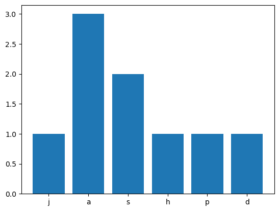

```python
a=input().replace(" ","")
a=a.lower()
dictOut = {}
for char in a:
    if char in dictOut:
        dictOut[char] += 1
    else:
        dictOut[char] = 1
print(dictOut)
chars = list(dictOut.keys())
count = list(dictOut.values())
plt.bar(range(len(dictOut)), count, tick_label=chars)
plt.show()
```

### QUESTION 11

### 11. Remove Duplicates

- Write a program to remove duplicate elements from a list while maintaining the order of elements.
- Calculate the mean and median of the unique elements.

```python
listOfNumsDuplicate = [1,2,2,3,7,4,5,5,6,6,7,6,8,9]
frequencyOfNums = {}
for num in listOfNumsDuplicate:
    if num in frequencyOfNums:
        frequencyOfNums[num] = frequencyOfNums[num] + 1
    else:
        frequencyOfNums[num] = 1
listOfNums = list(frequencyOfNums.keys())
mean = sum(listOfNums) / len(listOfNums)
listOfNums.sort()
median = 0
if len(listOfNums) % 2 == 0:
    median1 = listOfNums[len(listOfNums)//2]
    median2 = listOfNums[len(listOfNums)//2 - 1]
    median = (median1 + median2)/2
else:
    median = listOfNums[len(listOfNums)//2]
print(mean,median)
```

```
5.0 5
```

### QUESTION 12

### 12. String Operations:

- Given a list of strings, write a Python function to:
- Find the longest string.
- Count how many strings start with a vowel.
- Visualize the distribution of string lengths using a histogram.

```
i am okay ok!
5
```

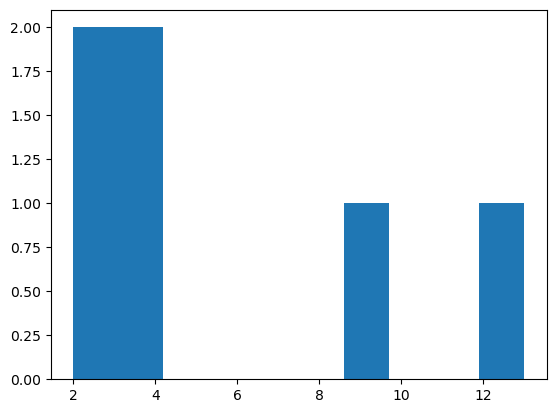

```python
import matplotlib.pyplot as plt
strings_list=["okay" , "okie" , "ok" , "okk" , "thumbs up" , "i am okay ok!"]
count = 0
lenArr = []
for string in strings_list:
    lenArr.append(len(string))
    if string.startswith(('A','E','I','O','U','a','e','i','o','u')):
        count += 1
maxLengthIndex = lenArr.index(max(lenArr))
print(strings_list[maxLengthIndex])
print(count)
plt.hist(lenArr)
plt.show()
```

### QUESTION 13

### 13. Sorting Dictionaries:

- Write a function to sort a list of dictionaries by a key.

Example:data = [{'name': 'Alice', 'age': 25}, {'name': 'Bob', 'age': 22}] Sort by age → [{'name': 'Bob', 'age': 22}, {'name': 'Alice', 'age': 25}]

```python
data = [{'name': 'Alice', 'age': 25}, {'name': 'Bob', 'age': 22}]
print(sorted(data,key=lambda k:k['age']))
```

```
[{'name': 'Bob', 'age': 22}, {'name': 'Alice', 'age': 25}]
```

### QUESTION 14

### 14. Word Filtering and Sorting:

Write a program to:

- Split a string into a list of words.
- Remove all words that are shorter than 4 characters.
- Sort the remaining words alphabetically.
- Visualize the word lengths using a bar chart.

```
['Hello', 'am', 'Jash', 'Pasad']
['Hello', 'Jash', 'Pasad', 'am']
```

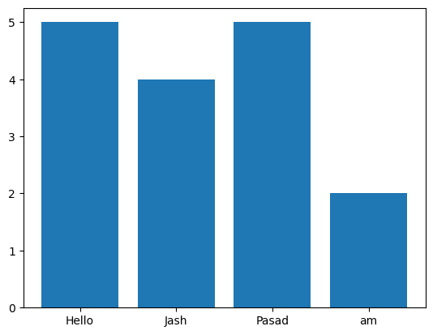

```python
import matplotlib.pyplot as plt
inputStr = input()
words = inputStr.split()
for word in words:
    if len(word) < 4:
        words.remove(word)
print(words)
words.sort()
print(words)
plt.bar(words,[len(word) for word in words])
plt.show()
```

### QUESTION 15

### 15. Anagram Finder:

Write a Python function to find all anagrams of a word in a given list.

Input: word = "listen", words = ["enlist", "google", "inlets", "banana"]

Output: ["enlist", "inlets"]

```python
inputWord = "listen"
words = ["enlist", "google", "inlets", "banana"]
sortedInputWord = sorted(inputWord)
output = []
for word in words:
    if sortedInputWord == sorted(word):
        output.append(word)
print(output)
```

```
['enlist', 'inlets']
```

### QUESTION 16

### 16. Set Operations:

Given two lists, write Python code to find their intersection, union, and symmetric difference. Visualize the results using Venn diagrams.

```python
import matplotlib.pyplot as plt
from matplotlib_venn import venn2
set1 = {1,2,3,4,5,6,7}
set2={2,4,6,8,10}
print(set1|set2)
print(set1&set2)
print(set1^set2)
set1 = set(set1)
set2 = set(set2)
venn2([set1, set2], ('Set 1', 'Set 2'))
plt.show()
```

[output not shown]

### QUESTION 17

### 17. File Operations:

Write Python code to: Create a text file. Write a list of numbers to the file (one per line). Read the file and compute their sum.

### QUESTION 18

### 18. Word Count and Frequency:

Write a program to:

- Read a file and count the number of words in it.
- Find the most frequent word.
- Visualize the word frequencies using a bar chart.

```python
import matplotlib.pyplot as plt
handle = open("words.txt")
counts = dict()
for line in handle:
    words = line.split()
    for word in words:
        counts[word] = counts.get(word,0) + 1
bigcount = None
bigword = None
for word,count in counts.items():
    if bigcount is None or count > bigcount:
        bigword = word
        bigcount = count
print(bigword)
plt.bar(range(len(counts)), counts.values(), tick_label=counts.keys())
plt.show()
```

[output not shown]

### QUESTION 19

### 19. Random Number Generation:

Write a Python program to:

- Generate 100 random integers between 1 and 50.
- Save them in a text file, one per line.
- Read the file and compute the mean of the numbers.
- Visualize the distribution of the numbers using a histogram.

```
27.14
```

[figure not shown]

```python
import random
import matplotlib.pyplot as plt
randomNums = []
for i in range(100):
    randomNums.append(random.randint(1,50))
file = open('data2.txt','w+')
for randomNum in randomNums:
    file.write(f'{randomNum}\n')
file.close()
file = open('data2.txt','r')
content = file.read()
numS = content.split('\n')
sumNums = 0
dictNumFreq = {}
for num in numS:
    if len(num) != 0:
        sumNums = sumNums + int(num)
        if num in dictNumFreq:
            dictNumFreq[num] += 1
        else:
            dictNumFreq[num] = 1
print(sumNums/len(randomNums))
plt.hist(list(dictNumFreq.keys()),bins=10)
plt.show()
```

### QUESTION 20

### 20. CSV File Operations:

- Write Python code to read a CSV file and compute the sum of values in a specific column.
- Visualize the data using a line plot.

### QUESTION 21

### 21. Basic Statistics:

Write Python code to calculate:

- Mean, median, mode, and standard deviation of a list of numbers.
- Visualize the data using a box plot

### QUESTION 22

### 22. Normalization:

- Write a Python function to normalize a list of numbers to a range of 0 to 1.
- Visualize the normalized data using a line plot.

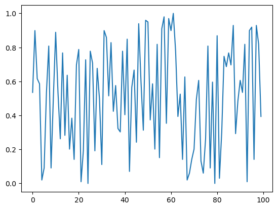

```python
import matplotlib.pyplot as plt
import random
Numbers_list = []
for i in range(100):
    Numbers_list.append(random.randint(1,100))
normalisedlist = []
for num in Numbers_list:
    normalisedlist.append((num-min(Numbers_list))/(max(Numbers_list)-min(Numbers_list)))
plt.plot(normalisedlist)
plt.show()
```

### QUESTION 23

### 23. Even or Odd:

- Write a Python program that takes an integer input from the user and prints whether the number is even or odd.

```python
n = int(input())
if n%2==0:
    print("Even Number")
else:
    print("Odd Number")
```

```
Even Number
```

### QUESTION 24

### 24. Grade Calculator:

- Write a Python program that takes a numerical grade (0-100) as input and prints the corresponding letter grade (A, B, C, D, F).

```python
marks = int(input())
if 80<=marks<=100:
    print("Grade = A")
elif 60<=marks<=79:
    print("Grade = B")
elif 40<=marks<=59:
    print("Grade = C")
elif 20<=marks<=39:
    print("Grade = D")
elif 0<=marks<=19:
    print("Grade = F")
else:
    print("Invalid Range")
```

```
Grade = C
```

### QUESTION 25

### 25.Leap Year Checker:

- Write a Python program that takes a year as input and checks if it is a leap year.

```python
year=int(input())
if year%100==0:
    if year%400==0:
        print("Leap Year")
    else:
        print("Not a Leap Year")
else:
    if year%4==0:
        print("Leap Year")
    else:
        print("Not a Leap Year")
```

```
Not a Leap Year
```